# Coursera Data Science Capstone

Finbark

2 April 2019

## Introduction

The purpose of the capstone project is to build an app that can predict the next word after one has been input. The Shiny framework was used.

The Shiny App:https://finbark.shinyapps.io/CourseraDataScienceCapstone/

Source code:https://github.com/Finbark/DataScienceCapstone

Source data:https://d396qusza40orc.cloudfront.net/dsscapstone/dataset/Coursera-SwiftKey.zip

## Methodology

Data was obtained from blogs, twitter, and news articles. This data was sampled to reduce the file size and then fed into the following process:

- Data cleaned by removing numbers, whitespace and punctuation, and by changing all text to lowercase.
- The cleaned data tokenised into a corpus using the TM Package.
- The corpus was then coverted into bi, tri, and quad n-grams, which are a sequence of contiguous n items from a given text.
- To predict off the n-grams, the Katz Back-off algorithm was used.

## Katz Back-off Algorithm

The algorithm works as follows:

- Load n-gram dataframes.
- Check if the input matches a stored quadgram. If so, return the next word.
- If no match, check the trigram dataframe and return if there is a match.
- Failing that, check the bigram dataframe and return if there is a match.

## The app itself

Below is an image of the app. It is a very simple design, where the user inputs their text in the left hand box and the prediction is displayed on the right.

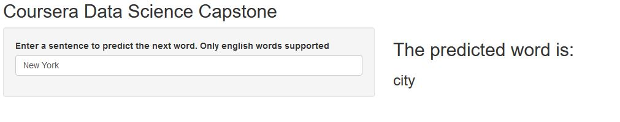

## Thanks very much

This concludes the presentation.